$$\renewcommand{\ket}[1]{|#1\rangle}$$ $$\renewcommand{\bra}[1]{\langle#1|}$$

# Quantum Computing: a crash course (Part I: Introduction and Foundations)

In this mini-course, we will try to understand the core elements of quantum computing from a "ground-up" approach. This means that while we may not cover everything that is new and exciting in the field, we will emphasize developing a better understanding of what is going on.

## The abstraction of information and computation

The subject of quantum computing sometimes comes across as "mysterious", often because of the reputation that quantum mechanics itself has of being "weird" or "mysterious". It may seem contrary to the name of "quantum computing", but in fact one does not need to know much (classical) physics to "understand" the fundamentals of quantum computing. Caveat: this may depend on what you mean by "physics"

> In this mini-course, we will try to understand quantum computing as a matter of processing "(quantum) information".

Through the lens of information and processing information, we can abstract the essence of quantum computing from "hard physics". To illustrate what I mean let us first discuss **classical information**

The mathematical foundation of classical information theory relies on the **classical bit**, which is simply a binary value of 0 or 1.

We can describe particular information states as strings of bits. There are certainly enough bit strings available to us to encode practically anything we want. At the very least, we can encode numbers as bitstrings through their binary representations. For example, "100" means 4 or "1001" means 9.

Suddenly, we have a way to "physically implement" encodings of numbers through bit representations. For example, we can use a sequence of ON/OFF switches, so that `ON , OFF , OFF` is a physical configuration representing the integer 4, and `ON, OFF , OFF , ON` is a physical configuration representing the integer 9.

[figure not shown]

We can also use coins, or magnetic charges, or basically anything with two distinct configurations to which we can map the bits 0 and 1. So, we can encode information as configurations of physical states. A "circuit" can be represented as a sequence of transformations we can apply to our physical encodings.

We can see now that there is a difference between talking about information and processing information via circuits, and how we can physically implement certain encodings and circuits (that act on a given physical encoding). This is one way in which we can abstract away the "hard physics" from quantum computing. The "hard physics" is required when one wishes to *implement* quantum computing, but not necessarily required to conceptualize it. Of course, physically implementing a classical bit is a trivality as it only requires the existence of two distinct configurations. We will see that the physical implementation of a "qubit" (a quantum bit) is less trivial, and requires us to accept quantum mecahnics.

Now we have a sense that we can encode information states and the processing of information into physical configurations and manipulations of physical configurations, we can flip it around and ask how our understanding of "physical reality" informs us about information processing. To what extent can we use arbitrary physical systems to encode information? Can we view a naturally occuring physical process as an extremely complicated computation being carried out on some encoded information?

Similar to how classical bits are indivisible units of classical information, we would like to also understand if we can make sense of a physical system that is as "simple as possible". By the way we've been holding this discussion, it seems reasonable to suggest that a "simplest possible physical system" should also somehow be tied to the simplest possible unit of information (a classical bit). This leads us to the **qubit**. Before we get into the definition of a qubit, note that a statement like "the simplest possible physical system", heavily depends on the model of physical reality we take. Currently, quantum mechanics and quantum formalism has been the most successful and comprehensive description of physical reality we have to date. Through quantum formalism, we can actually make sense of what we mean by "simplest possible physical system".

## A whirl-wind through quantum formalism, and the Qubit

A quantum description of physical systems is carried out with quantum formalism. Quantum formalism provides language for us to describe physical states, interaction between states and "measurements" of states.

### The postulates of quantum mechanics

Postulate 1: States

A state is a complete description of a physical system. Mathematically speaking, a state is a *ray* in some Hilbert space $\mathcal{H}$. The Hilbert space $\mathcal{H}$ is referred to as the state space. By a ray in a vector space, we simply mean equivalence classes of vectors in $\mathcal{H}$ defined by the equivalence relation of being scalar multiples of each other. Any such ray will always have a unique representative with unit norm, so we may freely identify rays in $\mathcal{H}$ with unit vectors in $\mathcal{H}$ modulo multiplication by $e^{i\theta}$ (i.e. up to a phase factor)

So, states can always be represented as vectors in a Hilbert space (which is a vector space). But on this Hilbert space, we also have an inner product $\langle - , - \rangle_{\mathcal{H}}$. However, taking the inner product between two states may depend on the choice of representative we take. Indeed, if we have two representatives $u$ and $v$, we have generally have that

$$ \langle u , v \rangle \neq \langle e^{i \theta_{1}} u , e^{ i \theta_{2}} v \rangle = e^{i (\theta_{1} - \theta_{2} ) } \langle u, v \rangle $$

Regardless, the *complex norm* of the inner product between states is well defined. Since $| e^{i \theta} | = 1$ for any $\theta \in \mathbb{R}$:

$$ | \langle u , v \rangle | = | \langle e^{i \theta_{1}} u , e^{ i \theta_{2}} v \rangle | = | e^{i (\theta_{1} - \theta_{2} ) }| \cdot | \langle u, v \rangle | $$

**Therefore, the inner product between states is well-defined up to a global phase factor.**

One can think of the inner product as providing the formalism for characterizing the distinguishability of different states. If we consider classical information states to be encoded by bitstrings in $\mathbb{F}_{2}^{n}$, then Hamming distance between $a_{1} \cdots a_{n}$ and $b_{1} \cdots b_{n}$ can provide a measure for how different these bitstrings are. For example, $011$ and $010$ have Hamming distance $1$ from each other -- measured by the number of differing bits. Complementary bitstrings (for example, $000$ and $111$) are maximally distant from each other with respect to Hamming distance. Ultimately, a single classical bit can only be the same or different from another classical bit. For quantum states, we have a similar but more refined notion of state separation, and this is modelled by the inner product $\langle -,- \rangle_{\mathcal{H}}$ attached to the Hilbert space $\mathcal{H}$. For example, the notion of orthogonality allows us to express when two states are "maximally distinct". Note that orthogonality does not depend on choices of representative vectors in $\mathcal{H}$ of states, and so it is well-defined for states.

It is common to blur the line between a state being an equivalence class and representatives of states. When we speak of states, we will often equate the two points of view, with the understanding that states can be represented by unit vectors *up to a phase factor*.

#### Ket notation:

As you have probably seen before, quantum theorists like to use the Dirac Bra-Ket notation. The notation is inspired by the Riesz representation, in that the inner product gives us an identification between an inner product space and its dual space via the inner product. In Bra-Ket notation, state vectors are written as $\ket{\psi}$ and dual vectors are written as $\bra{\psi}$ (where $\bra{\psi}$ is dual to $\ket{\psi}$). This notation makes a lot of sense, in that $\bra{\psi} \ket{\psi} = \langle \psi, \psi \rangle_{\mathcal{H}} = | \psi |_{\mathcal{H}}^{2}$, and $\bra{\phi} \ket{\psi} = \langle \phi, \psi \rangle_{\mathcal{H}}$.

Now that we have an understanding of states and how states are modelled with vectors in a Hilbert space, we also naturally interested in the question of how states change over time. Before we continue, I would like the reader to appreciate the scale of these physical descriptions. Quantum mechanical formalism is an attempt to have an account for *all* physical processes. We may be accustomed to a more "classical" way of thinking, where we idealize a macro-system or process in order to think of one concept at a time -- but this will always inherently be just a partial description of what is happening. In the quantum mechanical description of physics, if anything has a physically observable signal *at all*, it must be accounted for by the quantum mechanical formalism. This leads us to what some might consider "postulate 0" of quantum mechanics: that all the change over time of a (closed) quantum mechanical system should always be reversible (ergodicity). The information content of a physical system from one point in time to the next will always be the same, only possibly "rearranged" (if you think that information can be lost, it is probably because there are physical signals that are leaving the realm of your consideration!). This will actually be important later, as it will feature in some of our quantum circuit designs (at this point, if you would like to look this up a bit more, you can look up "reversible computation"). The postulates of quantum mechanics given here describe a "closed quantum mechanical system". There is a more flexible collection of postulates for what is known as an "open quantum mechanical system", where the possibility of an environment external to the system at hand exists.

This leads us to another postulate of quantum mechanical formalism, which describes time evolution of quantum states. At the heart of it, it says that if quantum states are "maximally distinct" (i.e. orthogonal) at some point in time, then they will remain "maximally distinct" at later points in time. That is, if we model the time evolution of a quantum state space $\mathcal{H}$ from one point in time to another as a linear operator $U(t): \mathcal{H} \rightarrow \mathcal{H}$, then $U(t)$ must be a *unitary operator*. Recall that the collection of unitary operators on a vector space is a Lie group, which has a Lie algebra $\mathfrak{u}_{n}$. This allows us to express the time evolution of a quantum mechanical system by way of an ODE, known as the *Schroedinger equation*: if $\ket{\psi(t)}$ denotes the time evolution of a quantum state, then $\ket{\psi(t)}$ satisfies the ODE

$$ \frac{d}{dt} \ket{\psi(t)} = - i H(t) \ket{\psi(t)} $$

The self-adjoint operator $H(t)$ above is known as the Hamiltonian of the system.

To summarize:

Postulate 2: Dynamics

Time evolution in quantum mechanics is described by a unitary operator. Equivalently, the time evolution of a quantum mechanical system is governed by Schroedinger's equation, for some self-adjoint matrix $H(t)$ (the Hamiltionian).

We've already alluded to a central concept above: as long as we properly keep track of everything involved in a physical system, all of our physical processes are reversible. This is what happens if we are dealing with a *closed* quantum system. Of course, in reality, we are constantly disregarding "insignificant" physical signals -- we should also have a way to model what is happening to a physical system in a scenario like this.

For example, if we are truly serious about accounting for literally all physical processes in our formalism, let's imagine what happens when an observer makes an observation, or takes a measurement. When taking a measurement of a quantum system, some kind of apparatus is set up (which itself is also some kind of quantum system, possibly macro in scale), interacts with the system of interest, and the resulting state of the apparatus system somehow encodes or represents the reading of some kind of measurement. After the measurement is done, the original quantum system is usually considered *without* the record of its interaction with the measuring apparatus (otherwise, we'd have to account for every measurement device the system has ever interacted with over all time -- past, present or future). Then, it seems like we are precisely violating the conditions that convinced us that all time evolution should be unitary -- it seems that we are (intentionally) discarding information about a quantum system when taking a measurement. So, when a quantum system $\mathcal{H}$ goes through a "measurement process" or "observation process", a possibly non-unitary operation $\mathcal{H} \rightarrow \mathcal{H'}$ is applied to the system at hand.

Hopefully it is apparent at this point that it is important it consider non-unitary operations acting on quantum systems as part of the quantum formalism. There is a way to formalize this properly through the concept of open quantum systems, and through the language of *quantum channels* and *quantum operations*. While there is indeed a way to characterize measurements of a quantum system through the intertwining of a system with an auxiliary system (considered as an "apparatus system") and then discarding or "tracing out" the apparatus system from the composite intertwined system, it can be less cumbersome and practical to include the notion of measurement as part of the postulates of quantum mechanics. If there is extra time, we may revisit this point of view with open quantum systems later.

Postulate 3A: Observables

Extending linear operators acting on a quantum system $\mathcal{H}$ beyond unitary operators, quantum mechanical formalism includes the notion of an *observable*. An observable of a quantum system $\mathcal{H}$ is a self-adjoint operator acting on state-vectors in $\mathcal{H}$. An observable of $\mathcal{H}$ is a transformation of $\mathcal{H}$ which represents some kind of physical property that can be measured.

Recall that from the Spectral theorem, any self-adjoint operator $\textbf{A} : \mathcal{H} \rightarrow \mathcal{H}$ has an orthonormal basis of eigenvectors $\{ e^{\textbf{A}}_{1}, \cdots, e^{\textbf{A}}_{n}\}$ with corresponding eigenvalues $\{ \lambda_{1} , \cdots , \lambda_{n} \}$. Therefore, we can write $A$ as the sum

$$ \textbf{A} = \sum \lambda_{k} E^{\textbf{A}}_{k} $$

where $E^{\textbf{A}}_{k}$ denotes the orthogonal projection of $\mathcal{H}$ onto the subspace generated by the eigenvector $e_{k}^{\textbf{A}}$.

Postulate 3B: Measurements

If the quantum state of a quantum system $\mathcal{H}$ just before a measurement if $\ket{\psi}$, the self-adjoint operator $\textbf{A}$ above measures $\ket{\psi}$ with outcome $\lambda_{k}$ with probability given by

$$ \mathbb{P}\big( \text{outcome }= \lambda_{k} \big| \ket{\psi} \big) = \big| E_{k}^{\textbf{A}} \ket{\psi} \big|^{2}_{\mathcal{H}} = \sum \lambda_{k} \bra{\psi} E_{k} \ket{\psi} $$

Then, given an obtained outcome $\lambda_{k}$ after measuring the observable $\textbf{A}$, the resulting (normalized) quantum system just after the measurement is

$$ \frac{E_{k}^{\textbf{A}} \ket{\psi} }{ |E_{k}^{\textbf{A}} \ket {\psi} | }. $$

Note that the measurement operation $\frac{E_{k}^{\textbf{A}} \ket \psi}{ \ket{E_{k}^{\textbf{A}} \ket \psi } } = \textbf{proj}_{E^{\textbf{A}}_{k}}( \ket{\psi} )$ is given by orthogonal projection of the state vector $\ket{\psi}$ onto the eigenspace $E_{k}^{\textbf{A}}$ of $\textbf{A}$. This is clearly not a unitary operation.

At this point, one may notice that this is the first time that we introduced any source of randomness into our description of quantum mechanics. Prior to this description of measurement, everything was completely deterministic. With respect to an observable $\textbf{A}$, a given (normalized) state-vector $\ket{\psi}$ describes a certain probability distribution of possible measurement outcomes for the observable $\textbf{A}$. That is, by decomposing $\ket{\psi}$ in terms of the orthonormal eigenbasis $\{ e_{1} , \cdots, e_{n} \}$ of $\textbf{A}$, we see that $\psi = a^{\psi}_{1} e_{1} + a^{\psi}_{2} e_{2} + \cdots + a^{\psi}_{n} e_{n}$ records an ordered tuple of complex numbers $(a^{\psi}_{1}, \cdots, a_{n}^{\psi})$ satisfying

$$ |a_{1}^{\psi} |^{2} + \cdots + |a_{n}^{\psi}|^{2} = 1 = | \psi |^{2}. $$

That is, the square norms $( |a_{1}^{\psi} |^{2} , \cdots , |a_{n}^{\psi}|^{2} )$ describe a (discrete) probability distribution, where $|a_{k}^{\psi}|^{2}$ is the probability that measuring the observable $\textbf{A}$ in the state $\ket{\psi}$ results in the outcome $\lambda_{k}$. Note that if $\textbf{A}$ is measured in an eigenstate $e_{k}$, then the result of the measurement is *deterministic*. The probability distribution of outcomes for this measurement will be $\lambda_{k}$ with probability $\big| E_{k}^{\textbf{A}} e_{k} \big|^{2}_{\mathcal{H}} = | e_{k} |^{2} = 1$ , and $\lambda_{j \neq k}$ with probability $0$.

> Where does the randomness come from? Recall that we previously described a measurement scenario for a quantum system $\mathcal{H}$ in terms of "intertwining" a quantum system with some kind of auxiliary apparatus system, and then "tracing out" or discarding the apparatus system from consideration. There is a certain coordinate-free canonical operation, defined for a joint/composite system (see the next postulate for the definition of a composite system) composed of the quantum system at hand and the apparatus system, called the *partial trace*. You can kind of think of this as "integrating out" the apparatus system, or taking a marginal probability summing out the system from consideration. This is all to say that when we discard an auxiliary system from consideration, we must do this in a canonical manner (or else we run the risk of introducing a coordinate-dependent notion). Inevitably, the result of the discarding of an auxiliary system from consideration truly does depend on the state of the auxiliary system itself. With no access to the auxiliary system (we've discarded it from consideration), what is left for the quantum system in consideration is a probability distribution over the resulting states that may occur from the process of tracing out the auxiliary system.

Finally, we come to our final quantum mechanical postulate (for now). This postulate is concerned with describing *joint* quantum systems: given quantum systems $\mathcal{H}_{A}$ and $\mathcal{H}_{B}$, what is the quantum system formed by considering both systems as part of a composite system?

Postulate 4: Composite Systems

Given quantum systems $\mathcal{H}_{A}$ and $\mathcal{H}_{B}$, the Hilbert space of states of the joint composite system is given by the tensor product of Hilbert spaces $\mathcal{H}_{AB} = \mathcal{H}_{A} \otimes \mathcal{H}_{B}$.

Recall that the tensor product of two inner product spaces is also an inner product space: for any $\psi_{A} \otimes \phi_{B} \in \mathcal{H}_{AB}$,

$$\langle \psi_{A} \otimes \phi_{B} , \psi'_{A} \otimes \phi'_{B} \rangle_{AB} = \langle \psi_{A} , \psi_{A}' \rangle_{A} \cdot \langle \phi_{B}, \phi_{B}' \rangle_{B}$$

$$\renewcommand{\ket}[1]{|#1\rangle}$$ $$\renewcommand{\bra}[1]{\langle#1|}$$

### Without further ado... The Qubit

There was a promise that somehow these quantum systems were supposed to help us describe the minimal type of physical system for which we can encode classical bits $0$ and $1$. Indeed, we can encode some classical bitstrings into some quantum states -- for example, a two state quantum system (i.e. a $2$-dimensional Hilbert space of states) can be fixed with a basis $\{ e_{0}, e_{1} \}$ (which correspond to eigenvectors for respective orthogonal projection operators). We can encode the classical bit "0" onto the state $e_{0}$ and the classical bit "1" onto the state $e_{1}$. Then, any other quantum state in this system is a superposition of $e_{0}$ and $e_{1}$, representing a probability distribution of the measurement outcomes of $0$ or $1$ when measuring the observable $\textbf{proj}_{ e_{0}, e_{1}}$ in this state. In light of the previous discussion above, a $2$-dimensional quantum system is quite literally the minimal physical context in which two distinct classical bits $0$ and $1$ can be encoded. We can finally now give the definition of a qubit. It is quite simple, and we have already given it in this paragraph. Let's just write it down a little more formally:

#### The definition of a qubit

A qubit (quantum bit) is a $2$-dimensional quantum system $\mathcal{H}$ with a distinguished basis of states $\mathcal{B} = \{ \ket{0} , \ket{1} \}$. The distinguished basis $\mathcal{B}$ is often referred to as the *computational basis*. These are the states in which we encode the classical bits $0$ and $1$.

> Example of an interesting state-vector: Suppose that $\mathcal{H}(1)$ is a quantum system corresponding to a single qubit. Then the state vector $\ket{+} := \frac{ \ket{0} + \ket{1} }{\sqrt{2}}$ is state for which when measuring the observable $\textbf{proj}_{ \ket{0} }$ in this state, we get the outcome of $1$ with probability $(\frac{1}{\sqrt{2}})^{2} = \frac{1}{2}$ and the outcome of $0$ with probability $(\frac{1}{\sqrt{2}})^{2} = \frac{1}{2}$. Upon measurement of $1$, the resulting state is $\frac{ \textbf{proj}_{\ket{0}} \ket{+} }{ | \textbf{proj}_{\ket{0}} \ket{+} | } = \frac{ 1/\sqrt{2} \ket{0} }{ 1/\sqrt{2} } = \ket{0}$. Upon measurement of $0$, the resulting state is $\frac{ \textbf{proj}_{\ket{1}} \ket{+} }{ | \textbf{proj}_{\ket{1}} \ket{+} | } = \frac{ 1/\sqrt{2} \ket{1} }{ 1/\sqrt{2} } = \ket{1}$. We say that the state $\ket{+}$ is in equal superposition of the computational basis states $\ket{0}$ and $\ket{1}$.

What about longer bitstrings?

Since we can take composite quantum systems, we can consider the quantum system $\mathcal{H}(n) = \mathcal{H}_{2^{n}} = \mathcal{H} \otimes \cdots \otimes \mathcal{H}$ (the $n$-fold tensor product). This is a $2^{n}$-dimensional Hilbert space, and has the composite computational basis $ \ket{ i_{1} \cdots i_{n} } = \ket{ i_{1} } \otimes \ket{ i_{2} } \otimes \cdots \otimes \ket{i_{n} }$ with $i_{j} = 0, 1$. We can encode bitstrings of length $n$ as computational basis states in the composite quantum system $\mathcal{H}(n)$. We will refer to any $n$-fold tensor product of qubits as a *qubit system*.

That's nice and all... but "why"??

We were originally interested in computation and information processing. This essentially boils down to bitstrings of arbitrary length and manipulations of bitstrings. Then, we described a bridge between physical manifestations of bits by way of encoding bits and bitstrings into physical systems. This led us to describe the smallest type of physical system into which classical information can be encoded. One might ask: are we straying too far away from our original interest in information processing by diving into all this quantum mechanics? Did we just describe a very complicated way to encode $0$ and $1$ into some kind of physical system? What's wrong with light switches?

Simply put, the quantum formalism is much more expressive than the classical formalism. Not only can we encode classical bitstrings as computational basis states of a qubit system, but we also get for free (as a consequence of this encoding) an interpretation of a general quantum state $\ket{\psi}$ in the system as a superposition of classical bitstrings. The squared-norms of the coordinates of $\ket{\psi}$ with respect to the computational basis $\{ \ket{ i_{1} \cdots i_{n} } \}_{i_{j} = 0,1}$ will always describe probability distributions for measurement outcomes of measuring $\ket{\psi}$ with respect to the computational basis (i.e. with respect to their corresponding projection operators, which are observables). However, there is much more than that. One can consider these probability distributions as a "classical shadow" of what it means for $\ket{\psi}$ to be a quantum state-vector which is in a superposition of the computational basis states.

While a probability distribution can always be associated to a state-vector (since we have a distinguished computational basis), it is *not* correct to describe a state-vector itself as a probability distribution over possible states. Recall that the coefficients $a_{j}^{\psi}$ are complex numbers -- to take the squared norm is inherently providing truncated information. Furthermore, possibly more importantly, a state-vector provides a probability distribution *only when an observable is specified*. In a qubit system, we have a global computational basis. This gives us a "default" collection of observables to measure state-vectors against, but these measurement proabilities are still something defined only once we have made such a choice.

So, state-vectors in quantum systems act more like a "lift" of classical probability distributions to quantum states. In fact, quantum formalism describes both state-vectors and the dynamics of state-vectors. We have a good understanding of how state-vectors interact with other states and with (other) physical systems. A solid understanding of the dynamics of state-vectors will allow us to design arbitrarily expressive quantum circuits. An interesting consequence of the dynamics of measurements in a quantum system is the notion of entanglement. Quantum entanglement is a feature of these quantum dynamics that can be heavily utilized to design interesting quantum circuits. Don't worry if the term "entanglement" barely means anything to you at this stage, We will shortly describe what this is.

One could perhaps say that quantum theory is an extension of classical probability theory, incorporating both the quantification of uncertainty but also an attempt to construct a complete model for the "things of this world" (and their dynamics) to which one could actually apply probability theory.

#### Physical implementations versus abstraction

You may ask: does this depend on too many unfounded assumptions about reality? What if we cannot actually find anything in "physical reality" that actually implements these postulates, or that behaves in the manner described above?

This where the "hard physics" can be separated from the understanding how (theoretical) quantum computation works. Of course, being able to actually build one is an important matter (and in fact people have succeeded in building such devices!). However, as long as the postulates of a quantum mechanical system are mathematically sound, we can view this in the abstract. For the most part, you can safely think of a qubit or a qubit system as an interesting "data structure", with attributes you can only probabilitistically probe at with statistical tests and have complex interactions with each other. After all, quantum systems (at least qubit systems) are "packages" of information (classical or quantum). To conceptualize quantum computation, one just needs to understand how to manage this information: how to probe at it, how to move things around, how they interact with each other...

To really illustrate this point, we can implement all of this inside our laptops in the language of Python! Qiskit is an industry standard, extremely popular (among quantum computing practioners) extensive Python library dedicated to developing quantum computing software. We are about to finally write our first line of code. But before we do, let me make a few remarks:

- With Qiskit, we can really view a qubit as some kind of funny and sophisticated data structure. We can define qubit objects in Qiskit, and they are defined to behave in the way described by the quantum mechanical postulates listed above. However, this is just a "simulation". Of course, when we take a measurement in Python, it cannot be truly random. So at the very least, randomness (an important aspect of quantum mechanics) is one area in which Qiskit should be viewed as a simulation. Another huge factor that is idealized in Qiskit (when compared to a physical implementation, if that is your end goal) is that physical systems, especially quantum ones are highly noisy. When we were describing "closed quantum systems" before, and unitary evolution -- we were imagining a highly idealized scenario where we can genuinely keep track of every single physical process that is involved with the physical system somehow. While noise simulations can be implemented in Qiskit, Qiskit operates with idealized closed quantum systems by default.
- You may ask yourself, "what is quantum software"? Even with the advent of quantum computers, there is still need for classical programs. An instructive way to imagine a "quantum circuit" is that a quantum circuit is some kind of controlled experiment one can set up so that given a certain "input state", we can expect to observe a very specific set of outcomes, or a distribution of possible outcomes for the experiment output. Classical programs assist us with "experiment setup". Especially if we have a complicated sequence of experiments, where the output of one experiment is fed as the input state into another following experiment, we can utilize classical programs to trigger certain experiment set-ups. These can even be made to be conditional on the measurement of some subset of output states produced by some prior experiment. Below is a schematic for how quantum dynamics and quantum circuits can be used in conjunction with classical programming to produce a fairly sophisticated "quantum program"...
> 1. Prepare input state
> 2. Let nature run its course, inside a "circuit" that is designed as an > environment that should produce some expected distribution of outcomes
>    - Some of the qubits can be measured, by some kind of measurement device. The measurements can be recorded into a classical register.
> 3. Classical automation or programming can set up a following circuit controlled on the readings from the prior classical register. Qubits that have not been measured can pass to this new circuit as well.
> 4. Final measurement stage: The rest of the qubits, or the required qubits are measured -- resulting in the final output of the composite circuit.

[figure not shown]

It should be noted that the final output of a quantum circuit does not have to be consist of a measurement. The output of a quantum circuit may simply be the quantum statevector which results from applying all the transformations in sequence, specified by the circuit. However, if we would like to "convert" this into classical information, a measurement will have to be taken.

As long as the "quantum programs" we write with Qiskit, do not involve inadvertently interfering with a quantum system when we do not mean to (i.e. we do not want to "collapse" any quantum states unless we mean to), then our set of Qiskit instructions should even be applicable and could be used in a realistic scenario, where the quantum circuits operate with *actual* physical qubits. Fortunately, Qiskit is a well designed programming langauge, with a decently secure type system -- it would be quite difficult to "accidentally" interfere with a quantum system in a way that we should not.

Now, we are finally ready to display some code. Unfortunately, the code will be quite boring...

```python
from qiskit import *
from qiskit.quantum_info import Statevector


## We can initialize a quantum circuit with a quantum register that only holds a single qubit.

first_circuit = QuantumCircuit(1)
```

```python
statevector = Statevector( first_circuit )
statevector.draw('Latex')
```

$$ |0\rangle$$

```python
### We can initialize the quantum register first. A quantum register can be initialized by specifying a size (in this case, this is a size two register).
### A quantum circuit can be initialized by passing in a quantum register. This is where a quantum circuit will hold the qubits that
### are to be used for the quantum circuit.


qreg = QuantumRegister(2)

qc = QuantumCircuit( qreg )

statevector2 = Statevector( qc )
statevector2.draw('Latex')
```

$$ |00\rangle$$

$$\renewcommand{\ket}[1]{|#1\rangle}$$ $$\renewcommand{\bra}[1]{\langle#1|}$$

Qiskit is designed so that one can only access and interact with qubits through an instance of a `Quantum Circuit`. The above circuits are not very interesting, as there are no gates placed on these circuits. They simply take the quantum system in its input state and does nothing with it. The `Statevector` constructor, constructs a state-vector object. We do not need to necessarily specify a dimension or initial state, we can instead pass in a quantum circuit object. If that is done, then by default Qiskit will initialize an initial state of $\ket{0 \cdots 0}$ (the "zero state" or "ground state") of the appropriate size for the inputted quantum circuit. The initial state is then passed through the inputted circuit. By the end of the circuit, we should have another complex state-vector which represents the output state of the circuit, starting with the zero state $\ket{0 \cdots 0}$. If you would ever like to work with another type of state, you would have to pass the qubit through a series of gates that would be cooked up in order to move a statevector from the initial state $\ket{0 0 0 \cdots 0 }$ to a desired state.

The line `statevector.draw('Latex')` will display a LaTeX representation of the final output state, as a complex vector (note that this is a representation of the output state-vector, which one can discern from interpreting the quantum circuits themselves). No measurements are happening when these final output state-vectors are displayed.

## Quantum Gates

Quantum gates are the building blocks with which we build up our quantum circuits. In the context of classical circuits, classical gates are basic logic gates used to build up more complex circuits. The standard classical gate set usually consists of the gates: `NOT`, `OR`, `AND`, `XOR`. These gates are characterized by their corresponding truth tables -- or equivalently, input state to output state associations. We want to consider building up a quantum gate set in a similar way -- we would like to consider a small collection of simple quantum unitary operations that are sufficiently easy to implement on a physical level, and they should be expressive enough to build up to any other kind of quantum unitary operation we may want to use. Recall that the evolution of a closed quantum system is always described by a unitary operation. Thus, we are really looking for a small collection of unitary operations that can serve as our basic set of gates.

$$\renewcommand{\ket}[1]{|#1\rangle}$$ $$\renewcommand{\bra}[1]{\langle#1|}$$ First, we can look into what a quantum variant of a simple NOT gate should look like. What would it mean for a gate to be a "quantum variant" of a basic gate?

The classical `NOT` gate acts on a single classical bit. It flips `0` to `1` and `1` to `0`. If we have encoded classical bits into quantum states $\ket{0}$ and $\ket{1}$ for a $1$-qubit system, then we would like the "quantum NOT" gate to be a unitary transformation that interchanges the states $\ket{0}$ and $\ket{1}$. Clearly, that unitary transformation is simply the swap matrix:

$$ X = \begin{pmatrix} 0 & 1 \\ 1 & 0 \end{pmatrix} $$

In quantum mechanics, this kind of unitary transformation holds a position of privilege as a "Pauli matrix". This one in particular is called a "Pauli-X matrix". Therefore, the gate here is called an "X-gate".

Below we demonstrate how to add an X-gate to a quantum circuit. When quantum circuits are initialized, the qubits are ordered and indexed. You can attach an X-gate with the following syntax, specifying which qubit you would like the X gate to apply to.

```python
qc = QuantumCircuit(1)
qc.x(0)

statevector = Statevector(qc)
statevector.draw('Latex')
```

$$ |1\rangle$$

$$\renewcommand{\ket}[1]{|#1\rangle}$$ $$\renewcommand{\bra}[1]{\langle#1|}$$

Recall that statevectors by default initialize to $\ket{0}$. So, by running $\ket{0}$ through the circuit above, the output state should be $\ket{1}$, which is what the `.draw('Latex')` method is displaying.

```python
## This is an example of a circuit that takes a 3-qubit system. X gates are applied only to the first and last qubits in the
## order of the register.

qc = QuantumCircuit(3)
qc.x(0)
qc.x(2)

statevector = Statevector(qc)
statevector.draw('Latex')
```

$$ |101\rangle$$

$$\renewcommand{\ket}[1]{|#1\rangle}$$ $$\renewcommand{\bra}[1]{\langle#1|}$$

Note that for a single classical bit, we can really only have two kinds of gates: the NOT gate, and the identity gate. We can readily see that this is not so, which is again a big difference in the expressiveness of qubits over classical bits. Recall that a single qubit constitutes a $2$-dimensional quantum system. This means that any $2 \times 2$ unitary matrix constitutes an admissible "gate" that can act on a single qubit. Whether or not certain gates are physically implementable is another question. This is an important reason why we would like to restrict ourselves to a small but "universal" set of gates we can build other gates up with.

Note that while the $X$-gate is a $1$-qubit gate, we can of course use it on single qubits within a multi-qubit system, as we have done above. This corresponds to using the tensor product of $X$-gates. For example, in the $3$-qubit system above, the gate we passed the system through corresponds to the unitary defined by $X \otimes I \otimes X$.

Recall that we had previously seen a qubit state that is in equal superposition of the computational basis states $\ket{0}$ and $\ket{1}$. Namely,

$$ \ket{+} = \frac{ \ket{0} + \ket{1} }{\sqrt{2}} $$

In fact, the state $\ket{+}$ is an eigenvector of the $X$-gate we described above, with eigenvalue of $1$. Indeed, it is easy to see that $ X \ket{+} = \ket{+}$. The other eigenvalue of the $X$-gate is $-1$. The corresponding unit eigenvector can be given as:

$$ \ket{-} = \frac{ \ket{0} - \ket{1} }{\sqrt{2}} $$

This gives us a basis for the $1$-qubit system, that is different from the standard computational basis. Furthermore, the corresponding change-of-basis transformation should give us an interesting $1$-qubit gate to consider. That is, we would like to describe the unitary transformation specified by $\ket{0} \mapsto \ket{+}$ and $\ket{1} \mapsto \ket{-}$. This defines the ever-important *Hadamard gate*.

$$ H = \frac{1}{\sqrt{2}} \begin{pmatrix} 1 & 1 \\ 1 & -1 \end{pmatrix} $$

The basis $\ket{+}$, $\ket{-}$ is sometimes referred to as the *Hadamard basis*.

$$\renewcommand{\ket}[1]{|#1\rangle}$$ $$\renewcommand{\bra}[1]{\langle#1|}$$

Now let's try something. We started with the computational basis, defined the $X$-gate (quantum NOT gate) in terms of computational basis, and then found that the $X$-gate had eigenvectors $\ket{+}$ and $\ket{-}$. What if we started with the Hadamard basis, defined the gate which swaps the two basis states, and then looked at the $+1$ and $-1$ eigenvectors for that?

If we did that, we would get the following eigenvectors:

$$ \frac{ \ket{+} + \ket{-} }{\sqrt{2}}, \frac{ \ket{+} - \ket{-} }{\sqrt{2}} $$

re-writing these in terms of the standard computational basis gives us:

$$ \frac{ (\ket{0} + \ket{1}) / \sqrt{2} + (\ket{0} - \ket{1})/\sqrt{2}}{\sqrt{2} } = \frac{1}{2} ( \ket{0} + \ket{0} ) = \ket{0} $$

$$ \frac{ (\ket{0} + \ket{1}) / \sqrt{2} - (\ket{0} - \ket{1})/\sqrt{2}}{\sqrt{2} } = \frac{1}{2} ( \ket{1} + \ket{1} ) = \ket{1} $$

Therefore, the map that swaps Hadamard basis vectors, with respect to the standard computational basis is simply:

$$ Z = \begin{pmatrix} 1 & 0 \\ 0 & -1 \end{pmatrix} $$

This is another Pauli matrix, this one is known as "Pauli-Z". Therefore, it is usually referred to as a "Z-gate".

We have now described three important $1$-qubit gates, $H$, $X$ and $Z$. The standard computational basis forms a basis of eigenvectors for the $Z$-gate and the Hadamard basis forms a basis of eigenvectors for the $X$-gate. For this reason, the standard computational basis is sometimes referred to as the "$Z$-basis" and the Hadamard basis is sometimes referred to as the "$X$-basis". Measuring a state vector "in the $X$-basis" (resp. $Z$-basis) means to measure a state vector with respect to the $X$-gate (resp. $Z$-gate).

$$\renewcommand{\ket}[1]{|#1\rangle}$$ $$\renewcommand{\bra}[1]{\langle#1|}$$

Now that we have some $1$-qubit gates up our sleeve, we can explore some quantum circuits that are slightly more interesting. Recall that the Hadamard states $\ket{+}$ and $\ket{-}$ can be measured in the $Z$-basis, resulting in an equally likely outcome of either $1$ or $-1$.

### Our first "program": quantum coin toss trials

```python
from qiskit_aer import AerSimulator


# Set up a quantum circuit that initializes n qubits (corresponding to the number of trials inputted)
# applies a Hadamard gate to each qubits.
# Measure final state with respect to the Z-basis. Report result as a string sequence of heads or tails coin toss outcomes
# Optional parameter: return_circuit is default to False, set to True to also return the coin tossing circuit

def quantum_coin_tosses(n, return_circuit = False):
    qc = QuantumCircuit(n)

    for qubit in qc.qubits:
        qc.h(qubit)


    qc.measure_all()

    job = AerSimulator().run(qc , shots=1, memory=True)
    result = job.result()
    memory = result.get_memory(qc)


    result_string = ''.join( ['H' if x == '1' else 'T' for x in memory[0] ] )

    return result_string, qc if return_circuit else result_string
```

```python
result, qc = quantum_coin_tosses(5, return_circuit=True)
print(result)
```

```
THHTT
```

Just like with state-vectors, Qiskit allows one to visualize a quantum circuit by using the `.draw` class method on a quantum circuit.

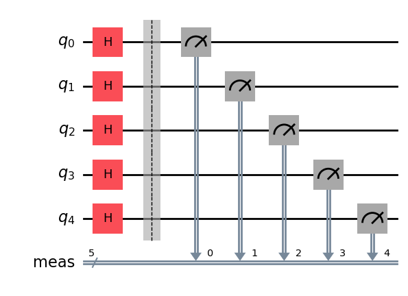

```python
qc.draw('mpl')
```

This is a typical representation of a quantum circuit. The diagram is read left to right. Each qubit gets a "wire", and on each of these wires you may see a sequence of gates. Each sequence of gates on a given wire is what is being applied, in order, to the qubit associated to the wire. The last operation being performed on each qubit wire above is the typical way to represent a measurement operation. The final row in the diagram above represents a register of classical bits that the program writes the measurement results into. The classical register holds the measurement results, and can be accessed by an observer or used as classical control for further programming.

Let's look at a quantum circuit diagram with some qubits passing through more than one gate.

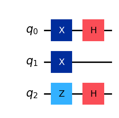

```python
qc = QuantumCircuit(3)

qc.x(0)
qc.h(0)
qc.x(1)
qc.z(2)
qc.h(2)

qc.draw('mpl')
```

$$\renewcommand{\ket}[1]{|#1\rangle}$$ $$\renewcommand{\bra}[1]{\langle#1|}$$

Quick exercise: Starting from the initial state $\ket{000}$, what is the resulting output state? Note that the *output state vector* is entirely deterministic. It is important to understand the difference: the output state here is deterministic, because we have not measured anything. If we choose to measure a qubit with respect to an observable, the outcome may be probabilistic.

$$\renewcommand{\ket}[1]{|#1\rangle}$$ $$\renewcommand{\bra}[1]{\langle#1|}$$

## Multi-qubit gates

Now that we have considered $1$-qubit gates, let's consider multi-qubit gates. Here we will start to see how the whole "reversibility" property of a closed quantum system plays an important role. Classically, multi-bit gates are gates like the `XOR` gate. We usually think of these gates as taking two bits and producing a single output bit -- however, this "functional" view on this gate stems from the fact that we "forget" the two input bits and only consider the single output bit. For this reason, we tend to think of these classical $2$-bit gates as being irreversible (the output of $1$ or $0$ could have come from multiple potential original states). In the quantum computing paradigm, we want all of our gates to be unitary, so a multi-qubit gate should act on a multi-qubit state and output a multi-qubit state as well. However, we will see shortly that we can still produce something like the `XOR` gate, through something called a "controlled gate".

### Controlled gates

We can think of partitioning a multi-qubit system so that a state $\ket{ i_{1} \cdots i_{k} | i_{k+1} \cdots i_{n} }$ can be read with the first $k$ qubits as representing "control" or "input states", and the last $n-k$ qubits as representing output states.

More specifically, we can define a controlled gate to be a gate whose output state is conditioned on the qubits in the "control register" -- the action of such a gate would be of the form $\ket{ i_{1} \cdots i_{k} | 0 \cdots 0 } \to \ket{ i_{1} \cdots i_{k} | j_{1} \cdots j_{m} } $.

#### CNOT/CX gate (Controlled NOT gate)

An important example of such a gate is the "controlled NOT" gate, or the "controlled X" gate. This is a $2$-qubit gate that is specified by:

$$ \ket{0|0} \mapsto \ket{0|0} $$ $$ \ket{0|1} \mapsto \ket{0|1} $$ $$ \ket{1|0} \mapsto \ket{1|1} $$ $$ \ket{1|1} \mapsto \ket{1|0} $$

which can be interpreted as "apply an $X$-gate to the qubit in the output register if the control qubit is in the state $\ket{1}$". This is a unitary gate with a $4 \times 4$ matrix representation in the computational basis (since it's a $2$-qubit gate) given by:

$$ \begin{pmatrix} 1 & 0 & 0 &0\\ 0 & 1 & 0 &0\\ 0 & 0 & 0 &1\\ 0 & 0 & 1 &0 \end{pmatrix} $$

We can form controlled versions of all of the other $1$-qubit gates that we have seen in a similar way, defining "CZ" (Controlled $Z$-gate), "CH" (controlled Hadamard gate), controlled rotation gates..etc.

#### The CCNOT/CCX gate (The Toffoli gate)

$$\renewcommand{\ket}[1]{|#1\rangle}$$ $$\renewcommand{\bra}[1]{\langle#1|}$$

#### An important side-bar: the no-cloning theorem

Now that we have become more acquainted with unitary evolution of quantum states, you may wonder what kinds of transformations are *not* permitted by the quantum mechanical postulates? This leads us to the famous "no-cloning theorem". It simply states that in a closed quantum mechanical system, the "copying" of the quantum state from one system to another is not permitted. In the context of qubit systems, we can say something more precisely. Suppose that $\mathcal{H}(2)$ is a $2$-qubit system, then there does not exist a unitary transformation $U$ and qubit states $\ket{\psi}$, $\ket{\phi}$ such that

$$ U ( \ket{\psi} \otimes \ket{\phi} ) = \ket{\psi} \otimes \ket{\psi} $$

$$\renewcommand{\ket}[1]{|#1\rangle}$$ $$\renewcommand{\bra}[1]{\langle#1|}$$

### A more interesting quantum circuit...Preparing an entangled state.

We have enough now to define a $2$-qubit quantum circuit, which takes the input state $\ket{00}$ to an *entangled state*. We will explain what this "entangled" interpretation is later, but for now we will simply demonstrate the circuit and describe explicitly what it does.

The $2$-qubit state $\ket{\Phi^{+}} = \frac{1}{\sqrt{2}} { \ket{00} + \ket{11} }$ is called a *Bell state*, or an EPR pair. Our goal is to write Qiskit implementation of a circuit that takes $\ket{00} \to \ket{\Phi^{+}}$. The code is presented below:

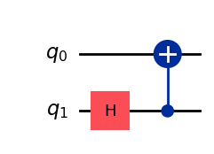

```python
qc = QuantumCircuit(2)

qc.h(1)
qc.cx(1,0)

qc.draw('mpl')
```

Again, we can use Statevector to trace out the circuit and mathematically represent the resulting deterministic output state:

```python
statevector = Statevector(qc)

statevector.draw( 'Latex' )
```

$$\frac{\sqrt{2}}{2} |00\rangle+\frac{\sqrt{2}}{2} |11\rangle$$

$$\renewcommand{\ket}[1]{|#1\rangle}$$ $$\renewcommand{\bra}[1]{\langle#1|}$$ Let us trace out this circuit. First, we input $\ket{00} = \ket{0} \otimes \ket{0}$. The gate $I \otimes H$ is applied to this input state, which results in

$$ \ket{00} \to \ket{0} ( \frac{\ket{0} + \ket{1}}{ \sqrt{2} } ) $$.

Then, we apply a controlled $X$-gate, controlled on the second qubit , targetting the first qubit. This maps

$$ \ket{0} ( \frac{\ket{0} + \ket{1}}{ \sqrt{2} } ) \to \frac{\ket{00} + \ket{11}}{ \sqrt{2} } $$

as desired. Exercise: what does this circuit do to the other computational basis states?

$$\renewcommand{\ket}[1]{|#1\rangle}$$ $$\renewcommand{\bra}[1]{\langle#1|}$$ Why is the Bell state $\ket{\Phi^{+}}$ called an entangled state? Recall that a tensor in the tensor product $\mathcal{H}_{1} \otimes \mathcal{H}_{2} \otimes \cdots \otimes \mathcal{H}_{k}$ is *decomposable* is it can be written in the form $v_{1} \otimes v_{2} \cdots \otimes v_{k}$ for vectors $v_{i} \in \mathcal{H}_{i}$. In the interpretation of quantum mechanics, this is to say that a state in a composite system, can be written as $k$ different states $v_{1},\cdots, v_{k}$ independently occuring in each state space $\mathcal{H}_{i}$. If a tensor is not decomposable, this means that we are considering a state of a composite system that cannot be expressed in terms of a composition of $k$ individual states from the systems $\mathcal{H}_{i}$.

So, when a composite system (such as a $2$-qubit system) is in an entangled state, then the joint state cannot be expressed as a product of states of the individual systems that make up the composite system.

### More fun with entanglement: dense coding and quantum "teleportation"

To illustrate more of the non-trivial novelty that comes along with entanglement, we now explain two popular applications of the Bell state: dense coding and quantum teleportation. Dense coding and quantum teleportation are sort of orthogonal to each other. Dense coding is about transmitting $2$ classical bits worth of information through the transmission of a single qubit, when the sender and receiver already share a pair of entangled qubits (in a Bell state together). Quantum teleportation is about using $2$ classical bits of information in order to transmit the entire state of a qubit. The fact that teleportation is possible is interesting: in spite of the *no-cloning theorem* (see the below side-bar), it is still possible to transmit the state of an unknown qubit to a receiver. Note that we can infer from the no-cloning theorem that when the qubit is transmitted to the reciever, the original qubit carried by the sender must be in a different state by the end of the process.

The schematic for both protocols are similar, and have the same initial set-up. In order to execute these protocols, Alice (the sender) and Bob (the receiver) must initially be sharing a pair of qubits that have been prepared in a joint system to be in a Bell state. That is, suppose we have a pair of qubits, and we put the composite system into the state

$$ \ket{\Phi^{+}} = \frac{ \ket{00} + \ket{11} }{\sqrt{2}}. $$

Then one of the physical qubits is sent to Alice, and the other is sent to Bob. To make this explicit in the notation, we can write $\ket{\Phi^{+}} = \frac{ \ket{0_{A}} \ket{0_{B}} + \ket{1_{A}} \ket{1_{B}} } {\sqrt{2}}$.

Then, as long as we don't interfere with the entangled joint state shared by the pair of qubits, the idea is for Alice and Bob to leverage this entangled state in order to achieve either dense coding or teleportation.

#### **Dense coding**

Suppose that Alice wants to transmit two classical bits of information to Bob. She can either transmit $00$, $01$, $10$ or $11$. Depending on which of the four options Alice wants to send, Alice will put her half of the entangled qubit pair through a specific gate. Note that as Alice only has access to one of the two qubits (say that they are ordered so that Alice's qubit is first in the qubit ordering of the system), she can only apply gates of the form $U \otimes I$ to the joint system.

##### What Alice does:

| Desired transmission | Gate applied by Alice | resulting state of the entangled pair |
| --- | --- | --- |
| $00$ | $I \otimes I$ | $\ket{\Phi^{+}} = \frac{\ket{00} + \ket{11}}{\sqrt{2}} $ |
| $01$ | $ X \otimes I$ | $\frac{ \ket{10} + \ket{01} }{\sqrt{2}}$ |
| $10$ | $ Z \otimes I$ | $\ket{\Phi^{-}} = \frac{ \ket{00} - \ket{11} }{\sqrt{2}}$ |
| $11$ | $Y \otimes I$ | $\frac{ -\ket{10} + \ket{01} }{\sqrt{2}}$ |

After applying the appropriate gate to her qubit in her half of the entangled pair, she sends her qubit to Bob.

##### What Bob does:

Once Bob receives Alice's qubit, he is in physical possession of both the qubits that make up the entangled pair. His task now is to first apply a CNOT/CX gate, followed by a $H \otimes I$. Both gates are to be applied to the composite system which make up the entangled pair. Depending on the state of the entangled pair, as prepared by Alice before she sent her qubit to Bob, the result of this gate sequence will have a different outcome.

$$\frac{\ket{00} + \ket{11}}{\sqrt{2}} \xrightarrow{ CX }\frac{\ket{00} + \ket{10}}{\sqrt{2}} = \frac{1}{\sqrt{2}}( \ket{0} + \ket{1} ) \otimes \ket{0} \xrightarrow{ H \otimes I} \ket{00}$$

$$\frac{ \ket{10} + \ket{01} }{\sqrt{2}} \xrightarrow{CX } \frac{\ket{11} + \ket{01}}{\sqrt{2}} = \frac{1}{\sqrt{2}}( \ket{0} + \ket{1} ) \otimes \ket{1} \xrightarrow{H \otimes I} \ket{01}$$

$$\frac{ \ket{00} - \ket{11} }{\sqrt{2}} \xrightarrow{CX } \frac{\ket{00} - \ket{10}}{\sqrt{2}} = \frac{1}{\sqrt{2}}( \ket{0} - \ket{1} ) \otimes \ket{0} \xrightarrow{ H \otimes I} \ket{10}$$

$$\frac{ -\ket{10} + \ket{01} }{\sqrt{2}} \xrightarrow{CX } -\frac{\ket{11} + \ket{01}}{\sqrt{2}} = \frac{1}{\sqrt{2}}( \ket{0} - \ket{1} ) \otimes \ket{1} \xrightarrow{ H \otimes I} \ket{11}$$

It is instructive to understand that this process is simply an example of "uncomputing". We can summarize the above protocol in the following way: the 2 classical bits are encoded into the basis states $ij \to \ket{ij}$ for $i,j = 0,1$. Recall that we had previously considered a circuit that took the state $\ket{00}$ to $\ket{\Phi^{+}}$. That circuit was given by $(CX) \circ (H \otimes I)$, which is precisely the same as the above protocol, in reverse order, if Alice wishes to transmit the two bits $00$. It is easy to see that $(CX)^{2} = I = ( H\otimes I)^{2}$, so that $( ( CX ) \otimes ( H \otimes I) )^{-1} = (H \otimes I ) \otimes (CX)$ Putting it together, we get

$$ \ket{00} \xrightarrow{ (CX) \circ (H \otimes I) } \ket{\Phi^{+}} \xrightarrow{ (H \otimes I) \circ (CX) } \ket{00} $$

The other pairs of classical bits get encoded into the other computational basis elements $\ket{01}$, $\ket{10}$ and $\ket{11}$. When passing these states into the Bell state preparation circuit, they get mapped to the corresponding bell state (Which are the states that Alice prepares for Bob before she sends her qubit to him). That is,

$$\ket{00} \to \frac{\ket{00} + \ket{11}}{\sqrt{2}} $$ $$\ket{01} \to \frac{ \ket{10} + \ket{01} }{\sqrt{2}}$$ $$\ket{10} \to \frac{ \ket{00} - \ket{11} }{\sqrt{2}}$$ $$\ket{11} \to \frac{ -\ket{10} + \ket{01} }{\sqrt{2}}$$

So, to recover the correct state which encode the classical bits, all Bob has to do is uncompute (i.e. run this state preparation circuit backwards) the Bell state preparation circuit.

Note that an implicit assumption that is made here is that both Alice and Bob have a consistently chosen computational basis for their qubits. That is, there is no ambiguity in how the classical bit strings are encoded as quantum states.

#### **Teleportation**

Now we describe the teleportation protocol. Suppose that Alice has a qubit $\ket{\phi} = a \ket{0} + b \ket{1}$ whose state she wants to send to Bob, using only the classical communication of 2 classical bits to Bob. The rough idea here is that the EPR pair, together with the qubit $\ket{\phi}$, will form a $3$-qubit joint system. Alice has access to 2 out of the 3 qubits in this joint system. Then, Alice can entangle $\ket{\phi}$ with her half of the EPR pair by passing these qubits through appropriate gates. Afterwards, Alice can perform a (partial) measurement operation by measuring the 2 qubits in her possession. This will put the $3$-qubit joint system into a specific post-measurement state. By transmitting Alice's measurement results, Bob will be able to recover the state $\ket{\phi}$ with the qubit in his possession by applying an appropriate gate to it, conditioned on the classical information received from Alice.

##### What Alice does:

Together with Alice's qubit $\ket{\phi}$, the starting state of the $3$-qubit joint system when the protocol begins is given by $$ \ket{\phi} \otimes \ket{\Phi^{+}} = \frac{1}{\sqrt{2}}( a \ket{0} \otimes ( \ket{00} + \ket{11} ) + b \ket{1} \otimes (\ket{00} + \ket{11} ) ) $$ $$ = \frac{1}{\sqrt{2}} ( a \ket{000} + a \ket{011 } + b \ket{100} + b \ket{111} ) $$

Then, Alice can apply a $CX \otimes I$ followed by a $H \otimes I \otimes I$ gate to the 2 qubits of the $3$-qubit system that are in her possession. The result of this will be:

$$ ( H \otimes I \otimes I )( CX \otimes I ) ( \ket{\phi} \otimes \ket{\Phi^{+}} ) = ( H \otimes I \otimes I ) ( \frac{1}{\sqrt{2}} ( a \ket{000} + a \ket{011 } + b \ket{110} + b \ket{101} ) ) $$ $$ = \frac{1}{2} \Big( a ( \ket{000} + \ket{011} + \ket{100} + \ket{111} ) + b ( \ket{010} + \ket{001} - \ket{110} - \ket{101} ) \Big) $$

$$ = \frac{1}{2} \Big( \ket{00} ( a \ket{0} + b \ket{1} ) + \ket{01} ( a \ket{1} + b \ket{0} ) + \ket{10} ( a \ket{0} - b \ket{1} ) + \ket{11} ( a \ket{1} - b \ket{0} ) \Big) $$

Notice that even though Alice has only applied gates to the 2 qubits in her possession, we have in fact acted on Bob's state in a non-trivial manner (by virtue of Bob's qubit being entangled with Alice's qubit). Now, if Alice measures her two qubits, she will obtain one of the four computational basis states $\ket{00}$, $\ket{01}$, $\ket{10}$ and $\ket{11}$ with equal probability. The joint system in the corresponding post measurement state of either $\ket{00} ( a \ket{0} + b \ket{1} )$ , $\ket{01} ( a \ket{1} + b \ket{0} )$ , $\ket{10} ( a \ket{0} - b \ket{1} )$ or $\ket{11} ( a \ket{1} - b \ket{0} )$. That is, Bob's qubit will then be in one of the four states: $( a \ket{0} + b \ket{1} )$ , $( a \ket{1} + b \ket{0} )$, $( a \ket{0} - b \ket{1} )$, or $( a \ket{1} - b \ket{0} )$.

##### What Bob does:

As Alice's actions has prepared Bob's qubit to be in one of four possible states, Bob can recover the state $\ket{\phi} = a \ket{0} + b \ket{1}$ for his qubit, if Alice transmits the measurement results to Bob.

| Bits from Alice | Bob's qubit state | Gate to apply |
| --- | --- | --- |
| 00 | $a\ket{0} + b \ket{1}$ | $I$ |
| 01 | $a \ket{1} + b \ket{0}$ | $X$ |
| 10 | $a \ket{0} - b \ket{1}$ | $Z$ |
| 11 | $ a \ket{1} - b \ket{0}$ | $Y = XZ$ |

It is easy to see that after Bob applies the appropriate gate to his qubit, the resulting qubit state will always be $\ket{\phi} = a \ket{0} + b \ket{1}$. Note that Alice no longer has possession of a qubit in the state $\ket{\phi}$ -- instead, her 2 qubits will together be in one of the four computational basis states.

### Some more examples of quantum gates and circuits

#### SWAP gate

The SWAP gate can be defined as a $2$-qubit transformation which acts on a $2$-qubit state in the following way:

$$ \ket{ q_{1} q_{2} } \mapsto \ket{ q_{2} q_{1} } $$

For example, $\ket{10} \mapsto \ket{01}$. Note that this is not the same thing as an $X$-gate!

```python
from qiskit import *
from qiskit.quantum_info import Statevector

swap_circuit = QuantumCircuit(2)


swap_circuit.cx(0,1)
swap_circuit.cx(1,0)
swap_circuit.cx(0,1)
swap_circuit.draw('mpl')


qc = QuantumCircuit(2)

qc.x(1)
qc.compose(swap_circuit, inplace=True)
statevector = Statevector( qc )


statevector.draw('Latex')
```

[output not shown]

#### Mod 2 carry adder

Let's consider a circuit that acts on a $3$-qubit state as follows:

$$ \ket{ c,a,b } \mapsto \ket{c, a, (a + b + c)\mod{2 }} $$

```python
adder_circuit = QuantumCircuit(3)

adder_circuit.cx(1,2)
adder_circuit.cx(0,2)


adder_circuit.draw('mpl')
```

[output not shown]